# TerraMax App Images Storage Account

## Overview

This is an Azure Storage Account for storing images to be used in the various apps in this project.

You can view exisiting images or add more by going to the Azure Portal and clicking on the `terramaxappimages` item in the list of Resources:

[figure not shown]

`terramaxappimages` in the Azure Portal

In the lefthand menu, select `Data storage` > `Containers` and then clicking on `images` in the list of containers. There is also a `$logs` container that was automatically generated as part of the resource.

[figure not shown]

`images` Container in the `terramaxappimages` Azure Storage Account

If you click on `images`, you will see a list of image files currently being hosted in the Storage Account. You can delete them, upload more images, or click on one at a time to view more details about the file or to copy the url for use elsewhere.

[figure not shown]

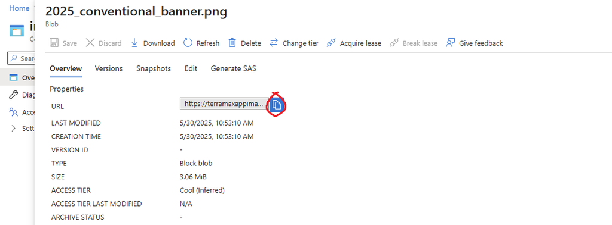

The images themselves aren’t displayed, but if you copy the url, open a new tab, and paste the url into the searchbar, then it will open a display of the image.

[figure not shown]

Viewing image in a new tab

If you change the name o fthe image file, it will change url address, and anywhere that uses the image will need to be updated accordingly.

## Settings

Here is a summary of the settings I used at creation, and the reasoning for why:

### Basics

| Setting | Value | Notes |
| --- | --- | --- |
| **Subscription** | Azure subscription 1 | ✅ Fine |
| **Resource Group** | TestResourceGroup | ✅ Fine (you can rename it later if needed) |
| **Location** | Central US | ✅ Good choice (low latency if your app is US-based) |
| **Storage Account Name** | terramaxappimages | ✅ Clear and purpose-specific |
| **Primary Service** | Azure Blob Storage / Data Lake Gen 2 | ✅ Blob Storage is exactly what you want |

### Performance and Replication

| Setting | Value | Notes |
| --- | --- | --- |
| **Performance** | Standard | ✅ Cheaper tier, perfect for static files |
| **Replication** | LRS (Locally-redundant) | ✅ Cheapest, fine for non-critical assets |

### Advanced

| Setting | Value | Notes |
| --- | --- | --- |
| **Hierarchical namespace** | Disabled | ✅ Good — needed only for advanced file systems (not images) |
| **SFTP / NFS / Cross-tenant replication** | All Disabled | ✅ Correct — not needed |
| **Access Tier** | Cool | ✅ Cost-optimized for infrequently accessed files (suitable if you rarely change these) |
| **Large file shares** | Enabled | ✅ Doesn’t hurt; ignored unless you use file shares, which you’re not |

### Security

| Setting | Value | Notes |
| --- | --- | --- |
| **Secure transfer** | Enabled | ✅ Recommended default |
| **Blob anonymous access** | Enabled | ✅ You want public access — this is required |
| **Storage account key access** | Enabled | ✅ Makes it easier to use from code if needed |
| **Entra (Azure AD) auth in portal** | Disabled | ✅ Fine — you don’t want to complicate access |
| **TLS 1.2** | ✅ Still industry standard |  |

### Networking

| Setting | Value | Notes |
| --- | --- | --- |
| **Public endpoint (all networks)** | ✅ What you need for public image hosting |  |
| **Microsoft network routing** | ✅ Recommended — more stable, no real downside here |  |

### Data Protection

| Setting | Value | Notes |
| --- | --- | --- |
| **Blob/Container/File soft delete** | Enabled (7 days) | ✅ Good safety net if you accidentally delete something |
| **Point-in-time restore / Change feed / Versioning** | Disabled | ✅ Fine — you’re not dealing with transactional data or version control |

### Encryption

| Setting | Value | Notes |
| --- | --- | --- |
| **Encryption type** | Microsoft-managed keys | ✅ Perfectly fine for non-sensitive image content |
| **Infra encryption** | Disabled | ✅ Not needed |